# Lecture 17 Part 1

Statistics 20

# R, RMariaDB/MySQL and sqlite

## Overview

- In this lecture, we will examine two methods for accessing SQL databases directly using R.
- In the first example, we will access a MySQL database with multiple tables and learn fundamental SQL commands. Additionally, we will create a MySQL Database in R.
- In the second example we will access a .sqlite file which contains a single large table.
- The point of this lecture is there is nothing magical about SQL and you can integrate it with many other languages (like R)

## MySQL with R

- MySQL (owned by Oracle) is the most dominant relational database management system (RDBMS) in the world with about 40% of the market.
- See https://www.mysql.com/ you will need access to a working copy for the first example to run. If you are on a Mac, you could consider Homebrew, but you need to know how to use terminal (https://brew.sh/)
- In other words, MySQL must be either installed on your own computer or you have access to a version on a computer that is not your own. Some possiblities are (a) your workplace or (b) a library latop CLICC
- (Note: If we were working directly with MySQL, a query consists of an SQL statement followed by a semicolon. If using MySQL through R, we do not need to use the semicolon)
- There are multiple libraries in R that work with MySQL
- Today’s example will use the library RMariaDB to issue SQL statements to a database. We will also need the DBI library and its function `dbConnect()` to access MySQL, login, issue a password and tell MySQL the name of our database:

## RMariaDB and DBI

- MariaDB is a relational database management system (RDBMS) and was written by the creators of MySQL after it was purchased by Oracle.
- It is highly compatible with MySQL and this library is reasonably well maintained
- DBI allows you to connect to a relational database with a username and password. MySQL is a server-based database. It usually lives on a remote server so we need to provide credentials like a host address, username, and password.

```r
# install.packages("DBI")
# install.packages("RMariaDB")

library(DBI)
library(RMariaDB)
```

## DBI example

- `dbConnect()` is from the DBI library and we give it the information it needs to use MariaDB to connect to our MySQL database.
- In this example, I have a pre-existing database named employees

```r
con <- dbConnect(
  MariaDB(),
  dbname = "employees",
  host = "127.0.0.1",  # allows my computer to talk to itself
  port = 3306, # specific communication channel used by MySQL
  user = "root", # my user account on MySQL on my computer
  password = "password" # my password for MySQL on my computer
)
```

## Schema of employees

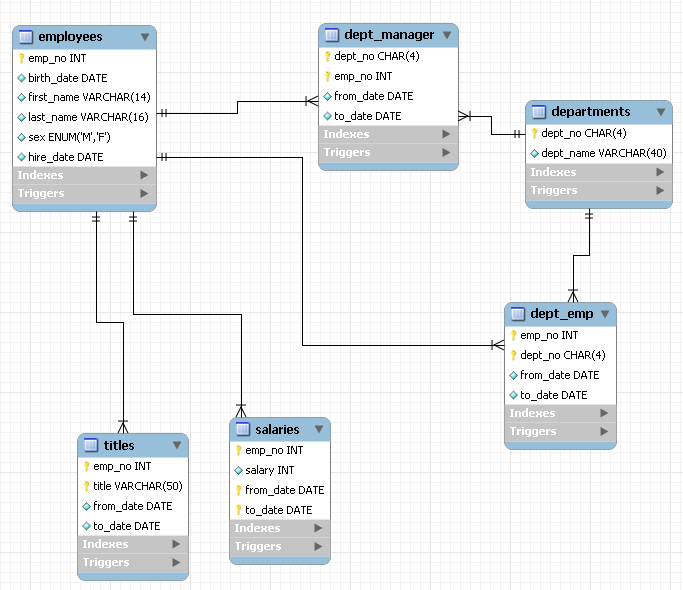

## Need Table Information

- A couple of functions are useful here if we did not know the database schema (structure).
- dbListTables tells us which tables are available

```r
dbListTables(con)
```

```
[1] "current_dept_emp"     "departments"          "dept_emp"
[4] "dept_emp_latest_date" "dept_manager"         "employees"
[7] "salaries"             "titles"
```

## And then field information

- dbListFields give us the names of the attributes in the specified table:

```r
dbListFields(con, 'employees')
```

```
[1] "emp_no"     "birth_date" "first_name" "last_name"  "gender"
[6] "hire_date"
```

```r
dbListFields(con, 'salaries')
```

```
[1] "emp_no"    "salary"    "from_date" "to_date"
```

- Once we have these pieces and understand their relatioship, the rest is about determining whether it is more efficient to write SQL code or R code to solve your problems.

# Basic MySQL queries and clauses in R

## Overview

- What you will notice is many of the data handling skills in SQL are things you have learned in R, the names are slightly different.
- It was developed at IBM in the early 1970s and commercialized by Oracle around 1980 and adopted as a standard in the 1980s.
- You can see its influence on R and also on Python and many other languages, even those designed to replace it.
- Keep the core concept in mind - complex data is represented by tables and by relationships between tables (examine the schema again)

## Structure of the language

- We write *Statements* in SQL and they consist of *clauses*
- Clauses start with a keywords and typically contain expressions and predicates
- Predicates can be true/false conditions, connected by logical operators like AND, OR, NOT
- Operators exit in SQL and include arithmetic (+, -, *, /), comparison (=, >, <, !=), and string operators (LIKE, IN, BETWEEN)

**We can write SQL code inside of R and it basically follows SQL rules**

## SELECT

We can extract all or some of a table and it is converted to a data frame using the function `dbGetQuery()`:

```r
t1 <- dbGetQuery(con, "SELECT * FROM employees") # there are over 300K
t1 |> head()
```

```
  emp_no birth_date first_name last_name gender  hire_date
1  10001 1953-09-02     Georgi   Facello      M 1986-06-26
2  10002 1964-06-02    Bezalel    Simmel      F 1985-11-21
3  10003 1959-12-03      Parto   Bamford      M 1986-08-28
4  10004 1954-05-01  Chirstian   Koblick      M 1986-12-01
5  10005 1955-01-21    Kyoichi  Maliniak      M 1989-09-12
6  10006 1953-04-20     Anneke   Preusig      F 1989-06-02
```

```r
dim(t1)
```

```
[1] 300024      6
```

- `SELECT * FROM employees` - SELECT is a statement-initiating keyword
- FROM is a keyword that introduces a subordinate clause within a statement
- The asterisk in this context is a wildcard. SQL “overloads” some of its symbols and keywords so they may mean differnt things in different contexts.

## LIMIT

- instead of bringing so much data in R, we could impose a limit on the number of rows:

```r
t1 <- dbGetQuery(con, "SELECT * FROM employees LIMIT 100")
dim(t1)
```

```
[1] 100   6
```

- LIMIT is a subordinate keyword which introduces an additional clause in this language.

## ORDER BY

Ascending sort by default, add the subordinate keyword DESC to reverse it.

```r
t2 <- dbGetQuery(con, "SELECT *
                           FROM     salaries
                           WHERE salary > 100000
                           ORDER BY salary DESC")
t2 |> head()
```

```
  emp_no salary  from_date    to_date
1  43624 158220 2002-03-22 9999-01-01
2  43624 157821 2001-03-22 2002-03-22
3 254466 156286 2001-08-04 9999-01-01
4  47978 155709 2002-07-14 9999-01-01
5 253939 155513 2002-04-11 9999-01-01
6 109334 155377 2000-02-12 2001-02-11
```

- The default here is ASC (ascending)

## WHERE

The data in this example is very manageable in terms of size, we could just use R to subset or use SQL to filter observations using the keyword WHERE

```r
t2 <- dbGetQuery(con, "SELECT *
                           FROM     salaries
                           WHERE to_date = '9999-01-01' ")
t2 |> head()
```

```
  emp_no salary  from_date    to_date
1  10001  88958 2002-06-22 9999-01-01
2  10002  72527 2001-08-02 9999-01-01
3  10003  43311 2001-12-01 9999-01-01
4  10004  74057 2001-11-27 9999-01-01
5  10005  94692 2001-09-09 9999-01-01
6  10006  59755 2001-08-02 9999-01-01
```

NOTE: look at how 9999-01-01 was quoted.

## OR and AND

- SQL has the OR and AND operators
- In this example, we are looking for two conditions (we could have more conditions):

```r
t3 <- dbGetQuery(con, "SELECT   first_name, last_name, gender
                           FROM     employees
                           WHERE    emp_no  > 11000 and  emp_no  < 12000
                           ORDER BY emp_no DESC, last_name")
t3 |>  head()
```

```
  first_name   last_name gender
1    Apostol Rabehasaina      F
2      Conal      Juneja      M
3       Heon    Mawatari      F
4   Ayakannu       Junot      M
5     Lenore       Comyn      M
6     Sigeru     Fiebach      F
```

## the IN operator

The IN operator can accept a list of values (typically string):

```r
t3 <- dbGetQuery(con, "SELECT   emp_no, title,  from_date,    to_date
                           FROM     titles
                           WHERE    title IN ('Senior Engineer', 'Senior Staff')" )
t3 |>  head()
```

```
  emp_no           title  from_date    to_date
1  10001 Senior Engineer 1986-06-26 9999-01-01
2  10003 Senior Engineer 1995-12-03 9999-01-01
3  10004 Senior Engineer 1995-12-01 9999-01-01
4  10005    Senior Staff 1996-09-12 9999-01-01
5  10006 Senior Engineer 1990-08-05 9999-01-01
6  10007    Senior Staff 1996-02-11 9999-01-01
```

## Pattern Matching - LIKE

LIKE performs matching on a given pattern, the percent sign works as a wild card, so here, “aa” can be anywhere in the string and case is ignored.

```r
t4 <- dbGetQuery(con, "SELECT   first_name, last_name, gender
                           FROM     employees
                           WHERE    first_name LIKE '%aa%' ")
t4 |>  head()
```

```
  first_name     last_name gender
1      Isaac Schwartzbauer      M
2      Aamod        Radwan      M
3    Behnaam       Srimani      F
4      Jaana        Veccia      F
5      Isaac          Pero      M
6      Aamer       Fraisse      M
```

## Using regular expressions with REGEXP

Here we are matching strings against a pattern, if you are familiar with PERL, this is similar:

```r
t6 <- dbGetQuery(con, "SELECT   first_name, last_name, gender
                           FROM     employees
                           WHERE    first_name REGEXP '^[aeiou].*' and last_name REGEXP '^[aeiou].*'
                           LIMIT    100" )
t6 |>  head()
```

```
  first_name    last_name gender
1   Arumugam Ossenbruggen      F
2       Eben    Aingworth      M
3       Ohad     Esposito      M
4      Akemi     Esposito      F
5 Aleksandar    Ananiadou      F
6   Alassane      Iwayama      F
```

the differences between LIKE and REGEXP are subtle. LIKE is much faster than REGEXP, so if you need to pattern match and write it with LIKE, choose LIKE. The advantage of REGEXP is that your pattern matching can be written to be highly specific (it will also be quite slow though).

## Working with multiple tables

Suppose now we wish to know which employees have the highest salaries We will need two different tables to answer that question.

### Indexes

Use indexes to improve the speed of data retrieval. An index is typically for columns used in JOIN, WHERE, and ORDER BY clauses.

```r
dbGetQuery(con, "SHOW INDEX FROM employees")
```

```
      Table Non_unique Key_name Seq_in_index Column_name Collation Cardinality
1 employees          0  PRIMARY            1      emp_no         A      299069
  Sub_part Packed Null Index_type Comment Index_comment Visible Expression
1     <NA>     NA           BTREE                           YES       <NA>
```

```r
dbGetQuery(con, "SHOW INDEX FROM salaries")
```

```
     Table Non_unique Key_name Seq_in_index Column_name Collation Cardinality
1 salaries          0  PRIMARY            1      emp_no         A      277922
2 salaries          0  PRIMARY            2   from_date         A     2611464
  Sub_part Packed Null Index_type Comment Index_comment Visible Expression
1     <NA>     NA           BTREE                           YES       <NA>
2     <NA>     NA           BTREE                           YES       <NA>
```

- There is a lot of vocabulary here outside of the scopre of Stats 20

## Indexing and Keys

```r
IJ <- dbGetQuery(con, "SELECT      first_name, last_name, gender, salary, to_date
                         FROM      employees INNER JOIN salaries
                           ON      employees.emp_no = salaries.emp_no
                        WHERE      to_date = '9999-01-01' and salary > 100000
                     ORDER BY      salary DESC
                        LIMIT      250" )
IJ |>  head(n=10)
```

```
   first_name last_name gender salary    to_date
1    Tokuyasu     Pesch      M 158220 9999-01-01
2     Honesty Mukaidono      M 156286 9999-01-01
3      Xiahua  Whitcomb      M 155709 9999-01-01
4      Sanjai    Luders      M 155513 9999-01-01
5     Tsutomu Alameldin      M 155190 9999-01-01
6     Willard      Baca      M 154459 9999-01-01
7      Lidong   Meriste      M 154376 9999-01-01
8    Charmane  Griswold      M 153715 9999-01-01
9     Weijing Chenoweth      F 152710 9999-01-01
10   Weicheng  Hatcliff      F 152687 9999-01-01
```

The FROM clause joins two tables because the query needs to pull information from both of them. We could also perform RIGHT and LEFT joins in MySQL.

## MySQL database creation and modification

We can create new databases using R and MySQL. This small dataset uses the officer involved shooting data from Los Angeles County. The assumption here is that we have 3 data.frames in R (deputies, persons and stations):

```r
deputies <- read.csv("data/deputies.csv")
persons <- read.csv("data/persons.csv")
stations <- read.csv("data/stations.csv")

str(deputies)
```

```
'data.frame':   432 obs. of  20 variables:
 $ INCIDENT_NUMBER               : int  1000345 1000483 1000290 1000527 1000340 1000502 1000296 1000656 1000413 1000490 ...
 $ INCIDENT_TYPE                 : chr  "HIT SHOOTING INCIDENT" "HIT SHOOTING INCIDENT" "NON-HIT SHOOTING INCIDENT" "HIT SHOOTING INCIDENT" ...
 $ INCIDENT_DATE                 : chr  "03/10/2011 08:35:00 PM" "04/07/2014 09:29:00 PM" "02/10/2010 09:45:00 PM" "02/13/2014 04:57:00 PM" ...
 $ INCIDENT_LOCATION             : chr  "3300 FAIRMAN ST" "900 PALM AVENUE" "1300 WEST 139TH STREET" "19100 ELBERLAND STREET" ...
 $ CITY                          : chr  "LAKEWOOD" "WEST HOLLYWOOD" "COMPTON" "West Covina" ...
 $ STATE                         : chr  "CA" "CA" "CA" "CA" ...
 $ ZIP                           : int  90723 90069 90222 91792 90063 90260 90059 90650 90706 92308 ...
 $ REPORTING_DISTRICT            : int  1323 977 2812 2910 278 334 6851 453 1332 3199 ...
 $ NUMBER_OF_PERSONS             : int  1 2 1 1 1 1 2 1 1 1 ...
 $ DEPUTY_GENDER                 : chr  "M" "M" "M" "M" ...
 $ DEPUTY_RACE                   : chr  "HISPANIC" "WHITE" "WHITE" "HISPANIC" ...
 $ DEPUTY_AGE                    : int  43 31 34 34 45 30 41 34 36 44 ...
 $ YEARS_OF_SERVICE              : int  20 12 8 9 16 9 4 16 6 17 ...
 $ DEPUTY_ASSIGNED_UNIT_NAME     : chr  "LAKEWOOD STN" "WEST HOLLYWOOD STN" "COMPTON STN" "WALNUT/SAN DIMAS STN" ...
 $ INVOLVED_IN_PREVIOUS_SHOOTINGS: chr  "N" "N" "N" "N" ...
 $ DISTRICT_ATTORNEY_ACTION      : chr  "LEGALLY JUSTIFIED" "LEGALLY JUSTIFIED" "" "LEGALLY JUSTIFIED" ...
 $ TRAINING                      : chr  "N" "Y" "N" "N" ...
 $ WEAPON_INVOLVED_CATEGORY      : chr  "A-4" "B-4" "A-2" "A-4" ...
 $ WEAPON_INVOLVED_CATEGORY_DESC : chr  "FIREARM:  Perception shooting, Suspect actions and/or other info suggest suspect was armed, Firearm not seen/not recovered" "WEAPON - OTHER:  Perception shooting, Suspect actions and/or info suggest suspect was armed, Weapon not seen/not recovered" "FIREARM: …
 $ NUMBER_OF_PREVIOUS_SHOOTINGS  : int  NA NA NA NA 5 NA NA NA 0 0 ...
```

```r
str(persons)
```

```
'data.frame':   287 obs. of  14 variables:
 $ INCIDENT_NUMBER            : int  1000472 1000380 1000467 1000332 1000654 1000324 1000299 1000379 1000365 1000449 ...
 $ PERSON_AGE                 : int  46 35 49 25 53 30 29 26 32 80 ...
 $ PERSON_RACE                : chr  "WHITE" "HISPANIC" "BLACK" "HISPANIC" ...
 $ MENTAL_HEALTH_CONCERNS     : chr  "N" "N" "N" "N" ...
 $ CRIMINAL_HISTORY           : chr  "Y" "Y" "Y" "Y" ...
 $ WOUNDED                    : chr  "N" "N" "N" "N" ...
 $ DECEASED                   : chr  "N" "N" "Y" "N" ...
 $ ON_PROBATION               : chr  "Y" "Y" "Y" "Y" ...
 $ ON_PAROLE                  : chr  "N" "Y" "Y" "Y" ...
 $ UNDER_THE_INFLUENCE        : chr  "N" "Y" "N" "N" ...
 $ SUBSTANCE_NAME             : chr  "" "ALCOHOL" "" "" ...
 $ NUMBER_OF_INVOLVED_DEPUTIES: int  1 1 2 1 1 1 1 2 1 1 ...
 $ APPROX_LATITUDE            : num  34.1 33.9 33.9 33.8 33.9 ...
 $ APPROX_LONGITUDE           : num  -118 -118 -118 -118 -118 ...
```

```r
str(stations)
```

```
'data.frame':   23 obs. of  10 variables:
 $ DEPUTY_ASSIGNED_UNIT_NAME: chr  "ALTADENA STN" "AVALON STN" "CARSON STN" "CENTURY STN" ...
 $ STATION                  : chr  "Altadena Sheriff" "Avalon Sheriff" "Carson Sheriff" "Century Sheriff" ...
 $ ST_NAME                  : chr  "Altadena" "Avalon" "Carson" "Century" ...
 $ S_ADDR1                  : chr  "780 E. Altadena Dr." "215 Sumner Ave." "21356 S. Avalon Blvd." "11703 S. Alameda Blvd." ...
 $ S_ADDR2                  : chr  "Altadena, CA 91001" "Avalon, CA 90704" "Carson, CA 90745" "Lynwood, CA 90262" ...
 $ S_PHONE                  : chr  "(626) 798-1131" "(310) 510-0174" "(310) 830-1123" "(323) 568-4800" ...
 $ S_FAX                    : chr  "(323) 415-7301" "(323) 415-7302" "(323) 415-7303" "(323) 415-7304" ...
 $ lat                      : num  34.2 33.3 33.8 33.9 33.9 ...
 $ lon                      : num  -118 -118 -118 -118 -118 ...
 $ HANDLING_UNIT_ID         : chr  "ALD" NA "CSN" "CEN" ...
```

## Connect with MySQL

We create a connection aliased as “mydb” (or any other alias will do). I have an account with a password and the location of the server (my computer).

```r
mydb <- dbConnect(MariaDB(), user='root', password='password', host='localhost')

dbSendQuery(mydb, "CREATE DATABASE stats20;")
```

```
<MariaDBResult>
  SQL  CREATE DATABASE stats20;
  ROWS Fetched: 0 [complete]
       Changed: 1
```

```r
dbSendQuery(mydb, "USE stats20;")
```

```
<MariaDBResult>
  SQL  USE stats20;
  ROWS Fetched: 0 [complete]
       Changed: 0
```

```r
dbWriteTable(mydb, value = deputies, name = "deputies", append = FALSE )
dbWriteTable(mydb, value = persons, name = "persons", append = FALSE )
dbWriteTable(mydb, value = stations, name = "stations", append = FALSE )

dbListTables(mydb)
```

```
[1] "deputies" "persons"  "stations"
```

## aliasing

- When you have many different tables with long names, aliasing `AS` may be helpful

```r
IJ2 <- dbGetQuery(mydb, "SELECT  deputies.INCIDENT_NUMBER, DEPUTY_RACE AS DRACE, persons.PERSON_RACE AS PRACE
                           FROM     deputies INNER JOIN persons
                             ON     deputies.INCIDENT_NUMBER = persons.INCIDENT_NUMBER " )
IJ2 |>  head()
```

```
  INCIDENT_NUMBER    DRACE    PRACE
1         1000345 HISPANIC    BLACK
2         1000483    WHITE    WHITE
3         1000483    WHITE    WHITE
4         1000290    WHITE HISPANIC
5         1000527 HISPANIC HISPANIC
6         1000340    WHITE HISPANIC
```

```r
table(IJ2$DRACE, IJ2$PRACE) # this is R
```

```
                    ASIAN-PACIFIC-ISL BLACK HISPANIC OTHER UNKNOWN WHITE
  ASIAN-PACIFIC ISL                 0     0        2     0       0     0
  ASIAN-PACIFIC-ISL                 0     1        4     0       0     1
  BLACK                             0     8       18     0       0     5
  FILIPINO                          0     1        1     0       0     0
  HISPANIC                          2    62      181     0       0    24
  WHITE                             1    42       86     1       1    36
```

# SQLite

## Example 2 using RSQLite to access a database stored in a file

- SQLite is a relational database engine that uses SQL as its query language and it is a lighter version of the client-server database model.
- SQLite is serverless, the data is stored in a single file, getting it to work is simple, best for “light” work

```r
## install.packages("RSQLite")
library(RSQLite)
```

## Access the driver

The driver defines which type of database you’re connecting to (e.g. SQLite, MySQL, etc). Each package provides a function to access the driver. The function to access driver is usually the same as the name of the DBMS:

```r
SQLite()
```

```
<SQLiteDriver>
```

You will still need to have the DBI library available

## Create a connection

The connection connects to a specific database, e.g. StudentTestScores within a database management system.

You make a connection with dbConnect(), the file database.sqlite is currently stored on my desktop, we will alias that information with con:

```r
con <- dbConnect(SQLite(), db='database.sqlite')
```

## examine contents

The dbListTables() function reveals the tables (there can be many) contained in your database. The dbListFields() function will give us the field names (columns) for a specified table:

```r
dbListTables(con)
```

```
[1] "Tweets"
```

Then check the fields within a table:

```r
dbListFields(con, "Tweets")
```

```
 [1] "tweet_id"                     "airline_sentiment"
 [3] "airline_sentiment_confidence" "negativereason"
 [5] "negativereason_confidence"    "airline"
 [7] "airline_sentiment_gold"       "name"
 [9] "negativereason_gold"          "retweet_count"
[11] "text"                         "tweet_coord"
[13] "tweet_created"                "tweet_location"
[15] "user_timezone"
```

## issue SQL commands to access the data

Just like before, once we know what is available, we can extract it. In the first example for junk1, we select every variable from the table Tweets and store it junk1:

```r
junk1 <- dbGetQuery(con, "SELECT * FROM Tweets")
names(junk1)
```

```
 [1] "tweet_id"                     "airline_sentiment"
 [3] "airline_sentiment_confidence" "negativereason"
 [5] "negativereason_confidence"    "airline"
 [7] "airline_sentiment_gold"       "name"
 [9] "negativereason_gold"          "retweet_count"
[11] "text"                         "tweet_coord"
[13] "tweet_created"                "tweet_location"
[15] "user_timezone"
```

## more complex example

- In this example, we select 6 variables from Tweets, alias some of them, reorder by count and save it to junk2.

```r
junk2 <- dbGetQuery(con, "SELECT name, retweet_count AS rtcount, text, tweet_created AS twcreated,
                    tweet_location AS twloc, user_timezone AS timezone
                    FROM Tweets
                    ORDER BY retweet_count DESC")
head(junk2)
```

```
            name rtcount
1          OBJ_3      44
2          OBJ_3      32
3    TatianaKing      31
4     airliners2      28
5 seattlefordguy      22
6        TheBuie      22
                                                                                                                                             text
1 @USAirways 5 hr flight delay and a delay when we land . Is that even real life ? Get me off this plane , I wanna go home 👠👠👠 (3 heel clicks)
2     @USAirways of course never again tho . Thanks for tweetin ur concern but not Doin anythin to fix what happened. I'll choose wiser next time
3                                        STOP. USING.THIS.WORD. IF. YOU'RE. A. COMPANY. RT @JetBlue: Our fleet's on fleek. http://t.co/Fd2TNYcTrB
4                                                                             @USAirways with this livery back in the day. http://t.co/EEqWVAMmiy
5                                                                                  @SouthwestAir beautiful day in Seattle! http://t.co/iqu0PPVq2S
6                                                                           can you not? RT @JetBlue Our fleet's on fleek. http://t.co/413GiAL0yl
                  twcreated                     twloc
1 2015-02-17 20:06:21 -0800
2 2015-02-17 20:50:56 -0800
3 2015-02-23 10:30:29 -0800              New York, NY
4 2015-02-22 11:46:36 -0800 Airports Around The World
5 2015-02-20 12:27:35 -0800              Bellevue, WA
6 2015-02-23 10:51:54 -0800               Raleigh, NC
                    timezone
1 Eastern Time (US & Canada)
2 Eastern Time (US & Canada)
3
4 Eastern Time (US & Canada)
5                     Hawaii
6 Eastern Time (US & Canada)
```

## Last thing: Disconnecting

This closes the connection, discards all pending work, and releases resources back to your system:

```r
dbDisconnect(mydb)
dbDisconnect(con)
```